# Stat_rethink Chapter 12

Mariana CHiozza

8/25/2020

# Monsters and Mixtures

## 12.1 OVER-DISPERSED COUNTS

When counts are more variable than a pure process (pure Gaussian)

The variance of a variable is called dispersion

Solution: Discover the omitted source of dispersion and include it in the model. There are two other strategies when no additional variables are available:

1. Continuous mixture models: A linear model is attached to a distribution of observations. Ex: beta-binomial and gamma-Poison (negative binomial)
2. Multilevels models: Estimate both, the residuals of each observation and the distribution of those residuals.

### 12.1.1 Beta-binomial

Each binomial count observation has its own probability of success. THere is a distribution of probabilities of success.

beta-distribution is a probability distribution for probabilities. It has two parameters: average probability (pbar) and theta.

```r
library(rethinking)
```

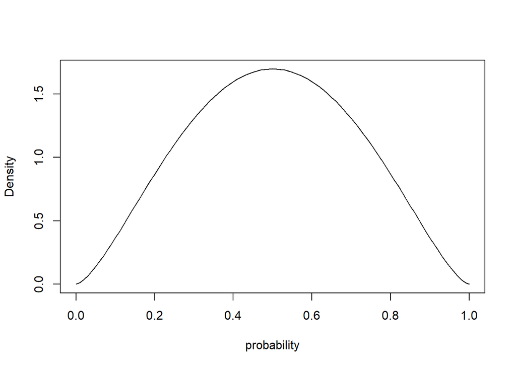

```r
pbar <- 0.5
theta <- 5
curve( dbeta2(x,pbar,theta) , from=0 , to=1 ,
    xlab="probability" , ylab="Density" )
```

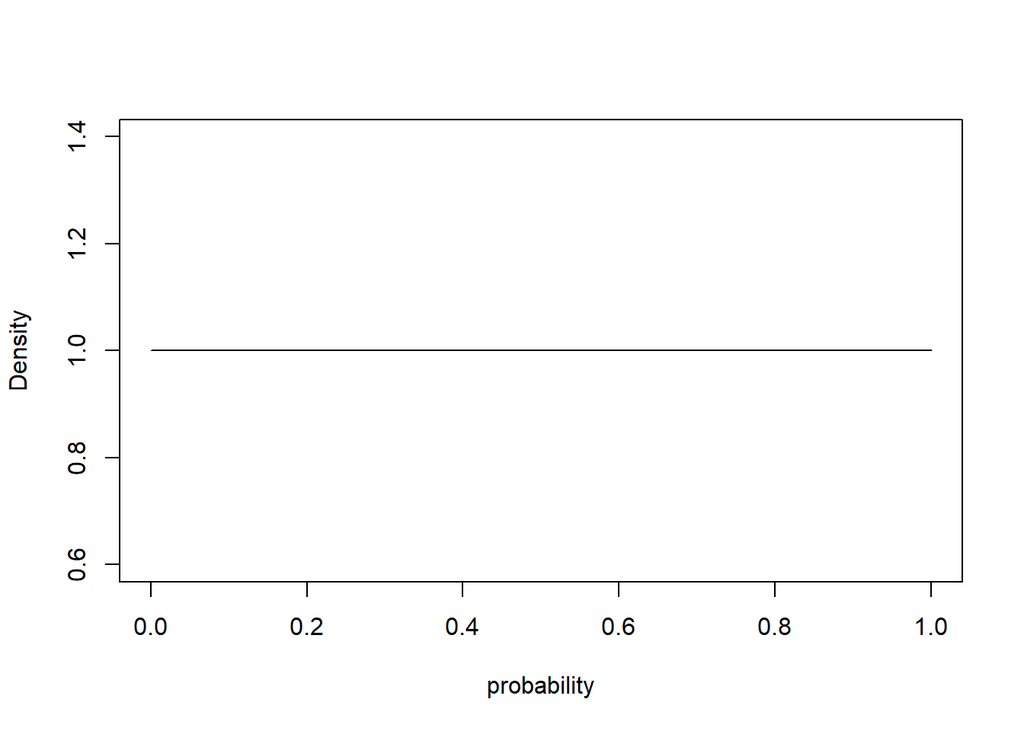

```r
pbar2 <- 0.5
theta2 <- 2
curve( dbeta2(x,pbar2,theta2) , from=0 , to=1 ,
    xlab="probability" , ylab="Density" )
```

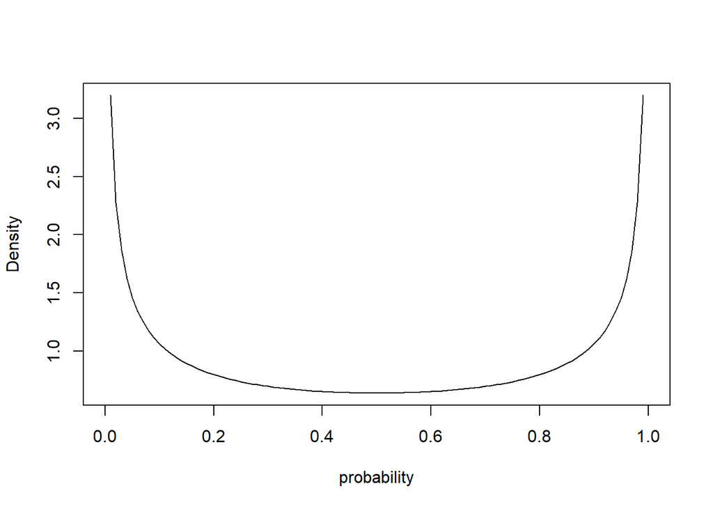

```r
pbar3 <- 0.5
theta3 <- 1
curve( dbeta2(x,pbar3,theta3) , from=0 , to=1 ,
    xlab="probability" , ylab="Density" )
```

Bind the linear model to pbar, so that changes in predictor variables change the central tendency of the distribution.

```r
library(rethinking)
data(UCBadmit)
d <- UCBadmit
d$gid <- ifelse( d$applicant.gender=="male" , 1L , 2L )
dat <- list( A=d$admit , N=d$applications , gid=d$gid )
m12.1 <- ulam(
    alist(
        A ~ dbetabinom( N , pbar , theta ),
        logit(pbar) <- a[gid],
        a[gid] ~ dnorm( 0 , 1.5 ),
        transpars> theta <<- phi + 2.0,
        phi ~ dexp(1)
    ), data=dat , chains=4 )
post <- extract.samples( m12.1 )
post$da <- post$a[,1] - post$a[,2]
precis( post , depth=2 )
```

```
##             mean        sd       5.5%    94.5%
## a[1]  -0.2799438 0.8247820 -1.1486692 1.443961
## a[2]  -0.2036732 1.4769810 -2.2090912 2.149618
## phi    0.7250842 0.4514502  0.1235176 1.369483
## theta  2.7250842 0.4514502  2.1235176 3.369483
## da    -0.0762706 1.6761589 -3.0423460 1.734261
##                                                                                                      histogram
## a[1]                                                  ▇▇▃▅▁▂▁
## a[2]                  ▁▂▂▂▂▇▁▁▁▂▃
## phi                                           ▇▃▃▂▃▅▅▁
## theta                                         ▇▃▃▂▃▅▅▁
## da    ▁▁▃▁▁▁▁▁▂▇▃▃▁
```

### 12.1.2 Gamma-Poison

Each Poison count observation has its own rate. It estimates the shape of a gamma distribution to describe the Poisson rates across cases.

Poisson distributions are very narrow. The variance muest equal the mean!!

Two parameters:

- mean (rate) = lambda
- dispersion (scale) of the rates across cases

Treat the very influencial points because gamma-Poisson expects more variation around the mean rate.

### 12.1.3 Over-dispersion entropy and information criteria

Should not use WAIC and PSIS with these models.

Recall, the beta-binomial and gamma-Poisson models implies the same latent probability for all of the applicants from the same row in the data. We can not disaggregate the data.

## 12.2 ZERO-INFLATED OUTCOMES

Incorporate processes to discriminate between zero outcomes which can come from the different processes. If total zeros are considered, the zeros will be inflated. EX: Zero manuscript done by monks in a day due to 1) drinking or 2) low rate of work.

Zero-inflated Poissonlikelihood = dzipois

```r
prob_drink<-0.2
rate_work<-1
N<-365

set.seed(365)
drink<-rbinom(N, 1, prob_drink)

y<-(1-drink)*rpois(N, rate_work)

m12.3 <- ulam(
    alist(
        y ~ dzipois( p , lambda ),
        logit(p) <- ap,
        log(lambda) <- al,
        ap ~ dnorm( -1.5 , 1 ),
        al ~ dnorm( 1 , 0.5 )
    ) , data=list(y=y) , chains=4 )
precis( m12.3 )
```

```
##           mean         sd      5.5%      94.5%    n_eff    Rhat4
## ap -1.25930136 0.33644298 -1.835370 -0.7916832 628.7897 1.001886
## al  0.01363265 0.08879909 -0.128364  0.1568024 577.0301 1.004940
```

```r
post <- extract.samples( m12.3 )
mean( inv_logit( post$ap ) ) # probability drink
```

```
## [1] 0.2263721
```

```r
mean( exp( post$al ) )       # rate finish manuscripts, when not drinking
```

```
## [1] 1.017733
```

## 12.3 ORDERED CATEGORICAL OUTCOMES

### Practice problems 12M1 and 12M2.

```r
employees <- 1:96
rate <- c('1', '2', '3', '4')
df <- data.frame(employees,rate)
df
```

```
##    employees rate
## 1          1    1
## 2          2    2
## 3          3    3
## 4          4    4
## 5          5    1
## 6          6    2
## 7          7    3
## 8          8    4
## 9          9    1
## 10        10    2
## 11        11    3
## 12        12    4
## 13        13    1
## 14        14    2
```

[output cut: 82 more lines]

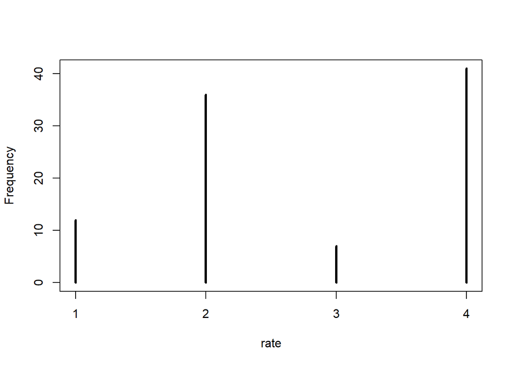

```r
df[c(1:12), 2] = "1"
df[c(13:48), 2] = "2"
df[c(49:55), 2] = "3"
df[c(56:96), 2] = "4"

df$rate <- as.numeric(as.factor(df$rate))

simplehist(df$rate , xlim=c(1,4) , xlab="rate")
```

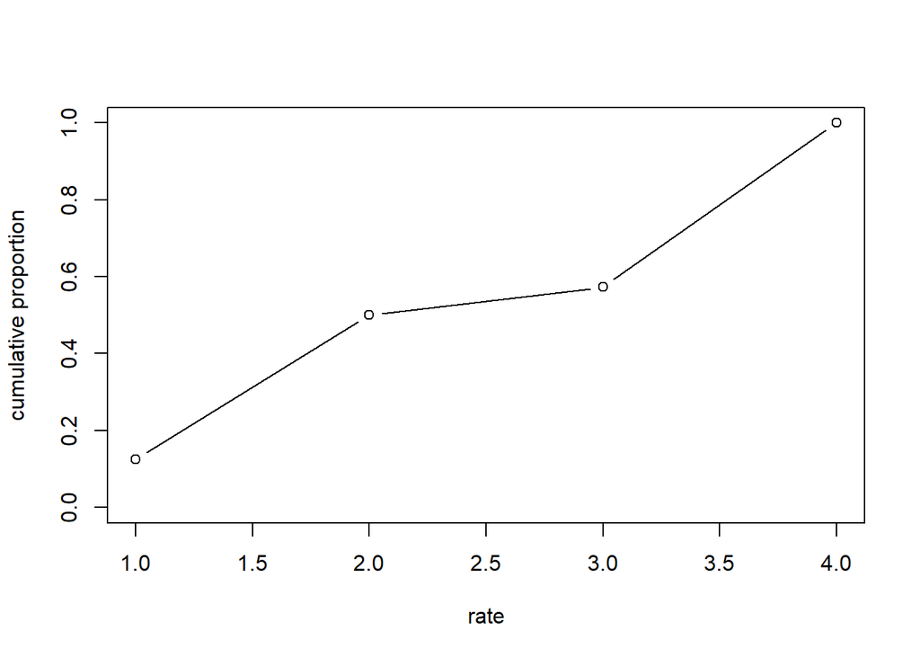

```r
# Discrete proportions
pr_k <- table(df$rate)/nrow(df)

# Cumulative proportions
cum_pr_k<-cumsum(pr_k)

#plot

plot(1:4, cum_pr_k, type="b", xlab="rate" ,
     ylab="cumulative proportion" , ylim=c(0,1) )
```

```r
logit<-(function(x) log(x/(1-x)))
round(lco<-logit(cum_pr_k) , 2)
```

```
##     1     2     3     4
## -1.95  0.00  0.29   Inf
```

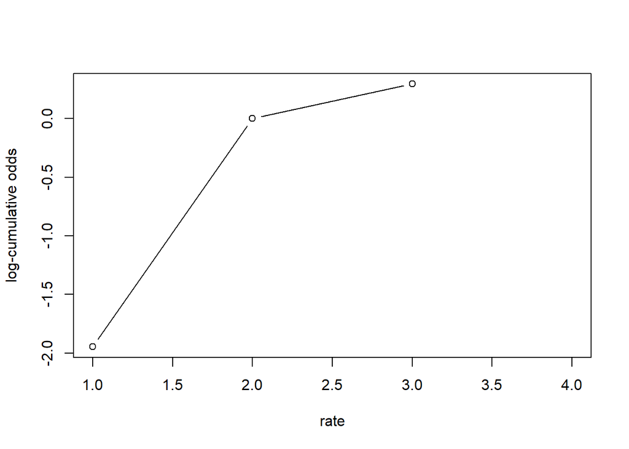

```r
plot(1:4, lco, type="b", xlab="rate" ,
     ylab="log-cumulative odds" )
```

```r
m12M2<-ulam(
    alist(
        R ~ dordlogit( 0 , cutpoints ),
        cutpoints ~ dnorm( 0 , 1.5 )
    ) , data=list( R=df$rate ), chains=4 , cores=4 )
precis(m12M2, depth = 2)
```

```
##                      mean        sd         5.5%      94.5%     n_eff     Rhat4
## cutpoints[1] -1.923083755 0.3011622 -2.411467944 -1.4736990  959.5881 1.0054605
## cutpoints[2]  0.002757369 0.2033085 -0.328703672  0.3313679 2049.3906 0.9987144
## cutpoints[3]  0.325901225 0.2034294  0.002797325  0.6582905 2333.0016 0.9992397
```

```r
round(inv_logit(coef(m12M2)) , 3)
```

```
## cutpoints[1] cutpoints[2] cutpoints[3]
##        0.128        0.501        0.581
```

### 12H1.

```r
library(rethinking)
data(Hurricanes)
d<-Hurricanes

dat <- list(
    D = d$deaths ,
    f = d$femininity )

# intercept only
m12H1 <- ulam(
    alist(
        D ~ dpois( lambda ),
        log(lambda) <- a,
        a ~ dnorm( 0 , 1 )
    ), data=dat , chains=4 , log_lik=TRUE )
precis(m12H1)
```

```
##       mean         sd     5.5%    94.5%    n_eff   Rhat4
## a 3.024835 0.02259303 2.988598 3.061722 663.5768 1.00547
```

```r
# Adding a predictor
m12.H1.1 <- ulam(
    alist(
        D ~ dpois( lambda ),
        log(lambda) <- a + b*f,
        a ~ dnorm( 0 , 1 ),
        b ~ dnorm( 0 , 1 )
    ), data=dat , chains=4 , log_lik=TRUE )
compare(m12H1, m12.H1.1, func = PSIS)
```

```
## Some Pareto k values are very high (>1). Set pointwise=TRUE to inspect individual points.
## Some Pareto k values are very high (>1). Set pointwise=TRUE to inspect individual points.
```

```
##              PSIS        SE    dPSIS      dSE     pPSIS      weight
## m12.H1.1 4383.183  987.0011  0.00000       NA 115.65496 1.00000e+00
## m12H1    4421.728 1066.7770 38.54505 145.2301  65.34518 4.26627e-09
```

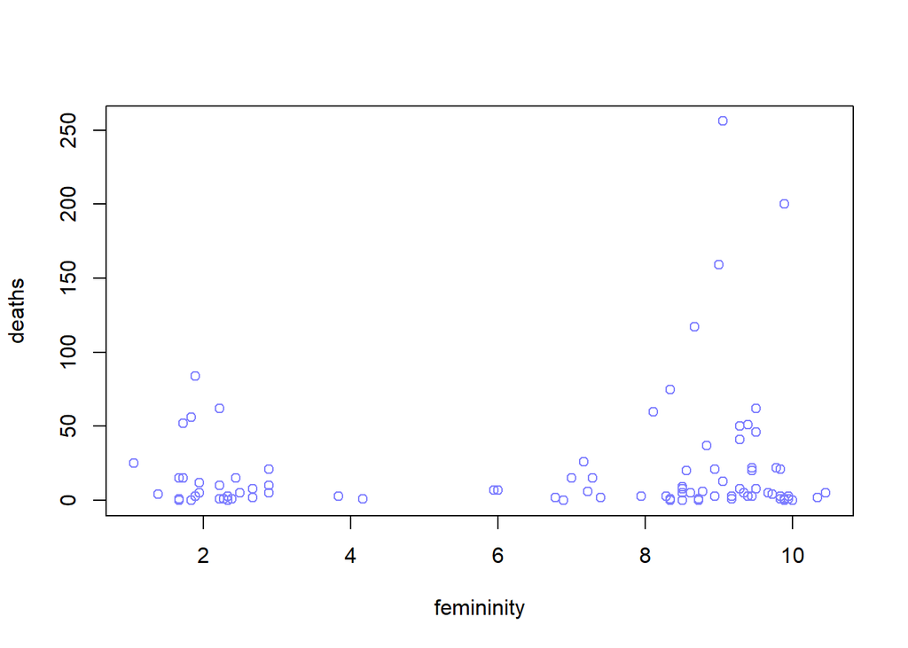

```r
plot( d$femininity , d$deaths , xlab="femininity" , ylab="deaths" ,
    col=rangi2)
```